# Reproducible Research: Peer Assessment 1

This paper shows some analysis on the data from a personal activity monitoring device as part of the Reproducible Reserach course at Coursera. As stated in the project description, this device collects data at 5 minute intervals through out the day. The data consists of two months of data from an anonymous individual collected during the months of October and November, 2012 and include the number of steps taken in 5 minute intervals each day. The dataset is stored in a comma-separated-value (CSV) file and there are a total of 17,568 observations in this dataset.

## Loading and preprocessing the data

The initial data set is loaded from the file and the structure of the data is inspected.

```r
initial.set <- read.csv("activity.csv")
str(initial.set)
```

```
## 'data.frame':    17568 obs. of  3 variables:
##  $ steps   : int  NA NA NA NA NA NA NA NA NA NA ...
##  $ date    : Factor w/ 61 levels "2012-10-01","2012-10-02",..: 1 1 1 1 1 1 1 1 1 1 ...
##  $ interval: int  0 5 10 15 20 25 30 35 40 45 ...
```

In the initial dataset, he date column is read as factor. It should be transformed from factor to date type object.

```r
initial.set[, 2] <- as.Date(initial.set[, 2])
str(initial.set)
```

```
## 'data.frame':    17568 obs. of  3 variables:
##  $ steps   : int  NA NA NA NA NA NA NA NA NA NA ...
##  $ date    : Date, format: "2012-10-01" "2012-10-01" ...
##  $ interval: int  0 5 10 15 20 25 30 35 40 45 ...
```

Further looking at the values in the interval column, I find the minimum interval per day is 0 and the maximum is 2355 and increment by 5. The value in the interval column represents the time of the day with 0 being 0:00 and 2355 being 23:55. I didn’t change the interval to time object since it is used in this analysis as identifier of the 5 minutes interval in a day.

## Mean total number of steps taken per day

To answer this question, all NA should be ignored and the total steps per day is calculated. To make the complete dataset tidy, I removed the interval column since it will not be used here.

```r
complete.set <- initial.set[complete.cases(initial.set),]

library(plyr)
total.completeset <- ddply(complete.set, "date", numcolwise(sum))
total.completeset <- subset(total.completeset, select = -c(interval))
head(total.completeset)
```

```
##         date steps
## 1 2012-10-02   126
## 2 2012-10-03 11352
## 3 2012-10-04 12116
## 4 2012-10-05 13294
## 5 2012-10-06 15420
## 6 2012-10-07 11015
```

The total number of steps taken per day is shown in the following plot:

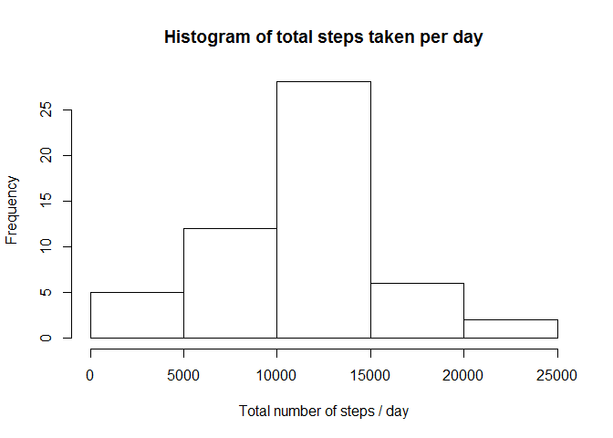

```r
hist(total.completeset$steps,
     xlab = "Total number of steps / day",
     main = "Histogram of total steps taken per day")
```

Calulcate the mean and the median of this total complete set data

```r
total.mean <- mean(total.completeset$steps)
total.median <- median(total.completeset$steps)
```

## The average daily activity pattern

Still using the complete dataset, the average number of steps taken across all days is calculated.

```r
average.completeset <- ddply(complete.set, "interval", numcolwise(mean))
```

Find the maximum average number of steps across all the days:

```r
max.average <- average.completeset[average.completeset$steps ==
                                   max(average.completeset$steps),]

#readable time
readabletime <- gsub("\\.", ":", toString(max.average$interval / 100))
```

The 5-minute interval with maximum average number of steps across all the days is 835 which is starting at 8:35

Here is the time series plot of the averaged data:

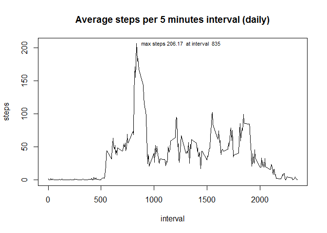

```r
with(average.completeset,
     plot(interval, steps, type="l",
          main="Average steps per 5 minutes interval (daily)"))

text(max.average$interval, max.average$steps,
     paste("max steps",
     round(max.average$steps, 2), " at interval ", max.average$interval),
     pos=4, cex=0.7)
```

## Imputing missing values

All the analysis above using the complete data. All NA’s are removed. Checking the total rows of the missing values in the initial data set

```r
na.count <-sum(complete.cases(initial.set) == FALSE)
```

The total number of missing values in the dataset is 2304

Looking at the first rows of the initial data set

```r
head(initial.set)
```

```
##   steps       date interval
## 1    NA 2012-10-01        0
## 2    NA 2012-10-01        5
## 3    NA 2012-10-01       10
## 4    NA 2012-10-01       15
## 5    NA 2012-10-01       20
## 6    NA 2012-10-01       25
```

I use the mean value of interval (from the previous average data set) to fill in the missing values

```r
filled.set <- initial.set

for (i in which(is.na(filled.set$steps)))
        { filled.set[i, "steps"] <-
              average.completeset[average.completeset$interval ==
                                      filled.set[i, "interval"], "steps"]}
head(filled.set)
```

```
##       steps       date interval
## 1 1.7169811 2012-10-01        0
## 2 0.3396226 2012-10-01        5
## 3 0.1320755 2012-10-01       10
## 4 0.1509434 2012-10-01       15
## 5 0.0754717 2012-10-01       20
## 6 2.0943396 2012-10-01       25
```

Here is the historgram of the this filled data set

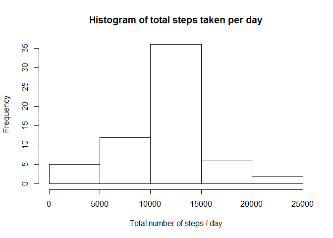

```r
total.filledset <- ddply(filled.set, "date", numcolwise(sum))

hist(total.filledset$steps,
     xlab = "Total number of steps / day",
     main="Histogram of total steps taken per day")
```

and calculating the mean and the median

```r
mean.filledset <- mean(total.filledset$steps)
median.filledset <- median(total.filledset$steps)
```

These values don’t differ so much from the estimates from the data set with NA removed. The mean stays the same ie. 10766 steps. The median changed slightly from 10765 to 10766.

## Differences in activity patterns between weekdays and weekends

First, I add a new column named daytype to the data set to get the weekday from the date and later replaced ‘Saturday’ and ‘SUnday’ with ‘weekend’ and the rest with ‘weekday’. And the later transform the daytype to factor.

```r
filled.set["daytype"] <- NA
filled.set$daytype <- weekdays(filled.set$date)

filled.set[grep("Saturday|Sunday", filled.set$daytype), "daytype"] <- "weekend"
filled.set[filled.set$daytype != "weekend", "daytype"] <- "weekday"

filled.set[, "daytype"] <- as.factor(filled.set[, "daytype"])

head(filled.set)
```

```
##       steps       date interval daytype
## 1 1.7169811 2012-10-01        0 weekday
## 2 0.3396226 2012-10-01        5 weekday
## 3 0.1320755 2012-10-01       10 weekday
## 4 0.1509434 2012-10-01       15 weekday
## 5 0.0754717 2012-10-01       20 weekday
## 6 2.0943396 2012-10-01       25 weekday
```

Calculate the average per interval

```r
average.filledset <- ddply(filled.set, .(interval, daytype), numcolwise(mean))
```

And the plot to show the comparison between the weeend and the weekdays

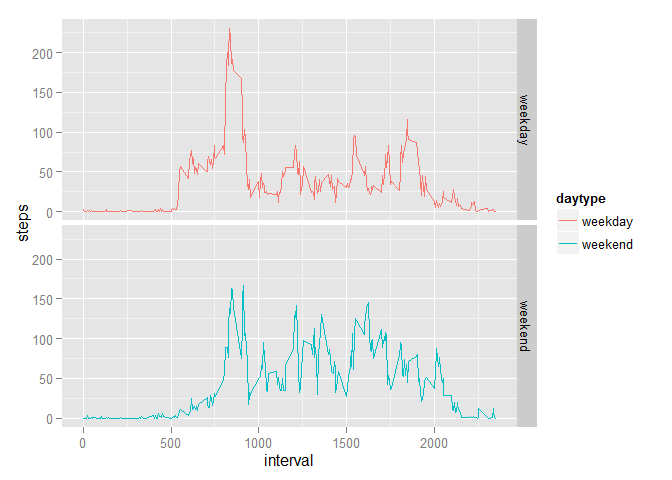

```r
library(ggplot2)
qplot(interval, steps, data = average.filledset,
      facets = daytype~., geom = c("line"), color=daytype )
```

It seems that this person makes more steps in the morning around 8 - 9 during the weekdays and more steps in the day hours in the weekend.